# Preparación y Cálculo de Índices Clínicos – LES

Fuensanta Bernal Gómez

2026-05-01

# 1 Introducción

El dataset contiene datos clínicos, analíticos y transcriptómicos de una cohorte de 252 pacientes con Lupus Eritematoso Sistémico (LES), junto con la expresión génica de la firma del interferón del grupo control. Este documento describe la importación del dataset DataSet_bruto y el cálculo de los cinco índices clínicos en los pacientes con LES empleados en el estudio: **SLEDAI-2K**, **SLICC/SDI**, **SLE-DAS**, **LLDAS** y **DORIS**. Todos los cálculos de los índices clínicos se realizan siguiendo las definiciones publicadas en la introducción de este TFM.

# 2 Carga de paquetes

```r
paquetes <- c("readxl", "dplyr", "tidyr", "knitr", "kableExtra", "writexl", "DiagrammeR", "DiagrammeRsvg", "rsvg", "ggplot2")

for (pkg in paquetes) {
  if (!requireNamespace(pkg, quietly = TRUE)) install.packages(pkg)
  library(pkg, character.only = TRUE)
}
```

```
## Linking to librsvg 2.61.0
```

```r
select <- dplyr::select
filter <- dplyr::filter
```

# 3 Importación del DataSet_bruto

```r
library(readxl)
library(dplyr)

# ── 1. Leer con skip=2: fila 3 del Excel como cabecera automáticamente ──
DataSet_bruto <- read_excel("DataSet_Bruto.xlsx",
                            sheet   = "LES",
                            skip    = 2,          # salta fila grupos + fila nombres largos
                            col_names = TRUE,     # fila 3 = nombres cortos como cabecera
                            col_types = "text",   # todo como texto; se convierte después
                            .name_repair = "unique")

# ── 2. Eliminar la única columna vacía (columna 242 del Excel) ──
DataSet_bruto <- DataSet_bruto %>%
  dplyr::select(-matches("^\\.\\.\\.\\d+$"))   # elimina columnas ...242, etc.

# ── 3. Convertir tipos ──
DataSet_bruto <- DataSet_bruto %>%
  mutate(across(-c(id, id2, fechanac, fecha, fechadiag),
                ~ suppressWarnings(as.numeric(.)))) %>%
  mutate(
    fechanac  = as.Date(as.numeric(fechanac),  origin = "1899-12-30"),
    fecha     = as.Date(as.numeric(fecha),     origin = "1899-12-30"),
    fechadiag = as.Date(as.numeric(fechadiag), origin = "1899-12-30"),
    varon1    = factor(varon1, levels = c(0, 1), labels = c("Mujer", "Varón")),
    les       = factor(les,    levels = c(0, 1), labels = c("Control", "LES"))
  )

# ── 4. Resumen ──
cat("Dimensiones totales:", nrow(DataSet_bruto), "pacientes x", ncol(DataSet_bruto), "variables\n")
```

```
## Dimensiones totales: 276 pacientes x 241 variables
```

```r
cat("Pacientes LES:      ", sum(DataSet_bruto$les == "LES"),     "\n")
```

```
## Pacientes LES:       252
```

```r
cat("Controles sanos:    ", sum(DataSet_bruto$les == "Control"), "\n")
```

```
## Controles sanos:     24
```

# 4 Cálculo del SLEDAI-2K

El **SLEDAI-2K** (Systemic Lupus Erythematosus Disease Activity Index 2000) es la suma de las puntuaciones de 24 manifestaciones clínicas e inmunológicas, ponderadas según su gravedad (1, 2, 4 u 8 puntos) [@Gladman2002]. La puntuación total oscila entre 0 y 105 puntos, siendo los umbrales habituales: actividad leve (1–5), moderada (6–10), alta (11–19) y muy alta (≥20).

```r
# Los ítems item1-item24 ya están ponderados en el dataset DataSet_bruto
# (convulsión=8, artritis=4, erupción=2, fiebre=1, etc.)

DataSet_bruto <- DataSet_bruto %>%
  mutate(
    sledai = rowSums(select(., item1:item24), na.rm = TRUE)
  )

# Verificación: distribución del SLEDAI-2K en pacientes LES
DataSet_bruto %>%
  filter(les == "LES") %>%
  mutate(
    categoria_sledai = case_when(
      sledai == 0            ~ "Remisión (SLEDAI = 0)",
      sledai >= 1 & sledai <= 5  ~ "Actividad leve (1–5)",
      sledai >= 6 & sledai <= 10 ~ "Actividad moderada (6–10)",
      sledai >= 11 & sledai <= 19 ~ "Actividad alta (11–19)",
      sledai >= 20               ~ "Actividad muy alta (≥20)"
    ),
    categoria_sledai = factor(categoria_sledai, levels = c(
      "Remisión (SLEDAI = 0)",
      "Actividad leve (1–5)",
      "Actividad moderada (6–10)",
      "Actividad alta (11–19)",
      "Actividad muy alta (≥20)"
    ))
  ) %>%
  count(categoria_sledai, .drop = FALSE) %>%
  mutate(
    `%` = round(n / sum(n) * 100, 1),
    `N (%)` = paste0(n, " (", `%`, "%)")
  ) %>%
  select(`Categoría SLEDAI-2K` = categoria_sledai, `N (%)`) %>%
  kable(
    caption = "Tabla 1. Distribución de pacientes LES según categoría de actividad (SLEDAI-2K)",
    align = c("l", "r")
  ) %>%
  kable_styling(bootstrap_options = c("striped", "hover"), full_width = FALSE)
```

Tabla 1. Distribución de pacientes LES según categoría de actividad (SLEDAI-2K)

| Categoría SLEDAI-2K | N (%) |
| --- | --- |
| Remisión (SLEDAI = 0) | 109 (43.3%) |
| Actividad leve (1–5) | 122 (48.4%) |
| Actividad moderada (6–10) | 21 (8.3%) |
| Actividad alta (11–19) | 0 (0%) |
| Actividad muy alta (≥20) | 0 (0%) |

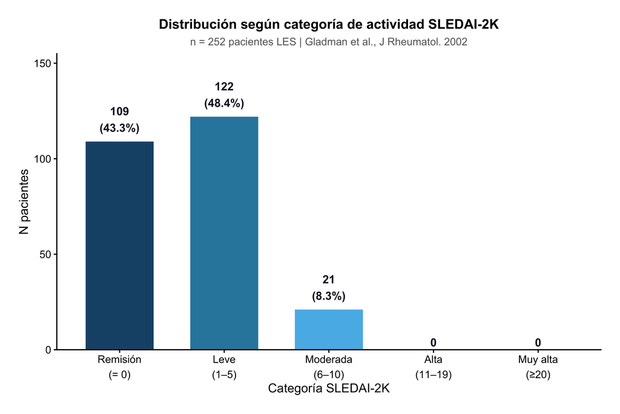

```r
sledai_df <- data.frame(
  categoria = factor(c("Remisión\n(= 0)", "Leve\n(1–5)", "Moderada\n(6–10)",
                        "Alta\n(11–19)", "Muy alta\n(≥20)"),
                     levels = c("Remisión\n(= 0)", "Leve\n(1–5)", "Moderada\n(6–10)",
                                "Alta\n(11–19)", "Muy alta\n(≥20)")),
  n    = c(109, 122, 21, 0, 0),
  pct  = c(43.3, 48.4, 8.3, 0.0, 0.0),
  fill = c("#1A5276","#2E86AB","#57B8E8","#D0D0D0","#F0F0F0")
)

ggplot(sledai_df, aes(x = categoria, y = n, fill = categoria)) +
  geom_col(width = 0.65, show.legend = FALSE) +
  geom_text(aes(label = ifelse(n > 0, paste0(n, "\n(", pct, "%)"), "0")),
            vjust = -0.4, size = 4.2, fontface = "bold", color = "#1A1A2E") +
  scale_fill_manual(values = sledai_df$fill) +
  scale_y_continuous(limits = c(0, 155), expand = c(0, 0)) +
  labs(
    title    = "Distribución según categoría de actividad SLEDAI-2K",
    subtitle = "n = 252 pacientes LES | Gladman et al., J Rheumatol. 2002",
    x        = "Categoría SLEDAI-2K",
    y        = "N pacientes"
  ) +
  theme_classic(base_family = "Arial", base_size = 13) +
  theme(
    plot.title    = element_text(face = "bold", size = 14, hjust = 0.5),
    plot.subtitle = element_text(size = 11, hjust = 0.5, color = "grey40"),
    axis.text.x   = element_text(size = 11, lineheight = 1.2),
    axis.text.y   = element_text(size = 11),
    plot.margin   = margin(20, 20, 20, 20)
  )
```

# 5 Cálculo del SLICC/SDI

El **SLICC Damage Index (SDI)** cuantifica el daño orgánico acumulado irreversible en LES desde el diagnóstico. Se calcula sumando los ítems de daño de 12 sistemas orgánicos (ítems sitem3, sitem9, sitem13, sitem19, sitem25, sitem30, sitem36, sitem43, sitem47–sitem50), según la fórmula publicada [@Gladman1996].

```r
DataSet_bruto <- DataSet_bruto %>%
  mutate(
    slicc = sitem3  + sitem9  + sitem13 + sitem19 +
            sitem25 + sitem30 + sitem36 + sitem43 +
            sitem47 + sitem48 + sitem49 + sitem50
  )

DataSet_bruto %>%
  filter(les == "LES") %>%
  count(slicc) %>%
  mutate(`N (%)` = paste0(n, " (", round(n / sum(n) * 100, 1), "%)")) %>%
  select(slicc, `N (%)`) %>%
  pivot_wider(
    names_from  = slicc,
    values_from = `N (%)`
  ) %>%
  kable(
    caption = "Tabla 2. Distribución de pacientes LES según puntuación de daño orgánico (SLICC/SDI)",
    align   = "c"
  ) %>%
  kable_styling(bootstrap_options = c("striped", "hover"), full_width = FALSE) %>%
  add_header_above(c("SLICC/SDI" = ncol(.)))
```

Tabla 2. Distribución de pacientes LES según puntuación de daño orgánico (SLICC/SDI)

| 0 | 1 | 2 | 3 | 4 | 5 | 6 |
| --- | --- | --- | --- | --- | --- | --- |
| 129 (51.2%) | 71 (28.2%) | 27 (10.7%) | 14 (5.6%) | 7 (2.8%) | 2 (0.8%) | 2 (0.8%) |

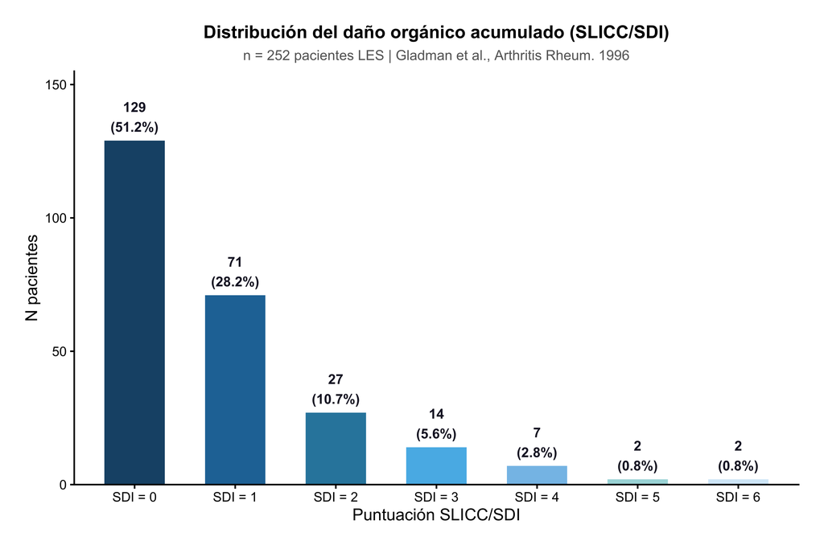

```r
slicc_df <- data.frame(
  sdi  = factor(paste0("SDI = ", 0:6), levels = paste0("SDI = ", 0:6)),
  n    = c(129, 71, 27, 14, 7, 2, 2),
  pct  = c(51.2, 28.2, 10.7, 5.6, 2.8, 0.8, 0.8)
)

cols_slicc <- c("#1A5276","#2374A5","#2E86AB","#57B8E8","#85C1E9","#A8DADC","#D6EAF8")

ggplot(slicc_df, aes(x = sdi, y = n, fill = sdi)) +
  geom_col(width = 0.6, show.legend = FALSE) +
  geom_text(aes(label = paste0(n, "\n(", pct, "%)")),
            vjust = -0.3, size = 3.8, fontface = "bold", color = "#1A1A2E") +
  scale_fill_manual(values = cols_slicc) +
  scale_y_continuous(limits = c(0, 155), expand = c(0, 0)) +
  labs(
    title    = "Distribución del daño orgánico acumulado (SLICC/SDI)",
    subtitle = "n = 252 pacientes LES | Gladman et al., Arthritis Rheum. 1996",
    x        = "Puntuación SLICC/SDI",
    y        = "N pacientes"
  ) +
  theme_classic(base_family = "Arial", base_size = 13) +
  theme(
    plot.title    = element_text(face = "bold", size = 14, hjust = 0.5),
    plot.subtitle = element_text(size = 11, hjust = 0.5, color = "grey40"),
    plot.margin   = margin(20, 20, 20, 20)
  )
```

# 6 Cálculo del SLE-DAS

El **SLE Disease Activity Score (SLE-DAS)** es un índice continuo de actividad que integra manifestaciones clínicas y analíticas [@Jesus2019]. Se calcula según la fórmula publicada por Jorge et al. y se categorizó en remisión (SLE-DAS ≤ 2.08), actividad leve (2.08 < SLE-DAS ≤ 7.64) y actividad moderada‑grave (SLE-DAS > 7.64), de acuerdo con las definiciones establecidas [@Jesus2021].

$$\begin{aligned}
\text{SLE-DAS} =\ & 0.366
+ 3.132 \times \text{Arthritis}
+ 0.454 \times \text{SJC}
+ 4.408 \times \text{MucocutVasculitis} \\
& + 3.138 \times \text{LocalRash}
+ 3.887 \times \text{GeneralRash}
+ 0.973 \times \text{Alopecia}
+ 2.769 \times \text{MucosalUlcers} \\
& + 0.754 \times \text{HypoC}
+ 0.956 \times \text{IncreasedAnti-dsDNA}
- 17.584 \times \text{PProt}
+ 3.811 \times \text{PProt} \times \ln(\text{Prot}) \\
& + 26.105 \times \text{Thromb}
- 5.577 \times \text{Thromb} \times \ln(\text{PlatCount}) \\
& + 6.118 \times \text{Leukopenia}
- 5.058 \times \text{Leukopenia} \times \ln(\text{LeukCount}) \\
& + 18 \times \text{Neuropsych}
+ 18 \times \text{SystemicVasc}
+ 18 \times \text{CardioPulm} \\
& + 9 \times \text{Myositis}
+ 6 \times \text{Serositis}
+ 9 \times \text{Hemolytic}
\end{aligned}$$

```r
# El cálculo del SLE-DAS requiere tres variables auxiliares antes de aplicar
# la fórmula principal. Su objetivo es preparar los términos logarítmicos
# para que no generen errores matemáticos cuando el evento clínico está ausente.
DataSet_bruto <- DataSet_bruto %>%
  mutate(
    # Variables auxiliares con logaritmos
    #1. PROTEINURIA AUXILIAR
    # La fórmula usa ln(proteinuria), pero si el paciente no tiene proteinuria
    # clínicamente relevante (sledas6 = 0), el valor es 0 y ln(0) = -Inf (error).
    # Solución: asignar el valor 1 cuando sledas6 = 0, ya que ln(1) = 0,
    # lo que anula el término sin afectar al resultado final.
    prot_aux  = ifelse(sledas6 == 0, 1, proteinuria),
    # 2. PLAQUETAS AUXILIAR
    # La fórmula requiere el recuento plaquetario en unidades de 10⁹/L.
    # Las plaquetas están registradas en x10³/µL (valores típicos: 150–400),
    # por lo que se dividen entre 1000 para obtener la escala correcta.
    # El término solo se activa cuando hay trombocitopenia (sledas14 = 1).
    plaq_aux  = sledas14 * (plaq / 1000),
    # 3. LEUCOCITOS AUXILIAR
    # Igual que las plaquetas: se convierten a 10⁹/L dividiendo entre 1000.
    # El término solo se activa cuando hay leucopenia (sledas15 = 1).
    leuc_aux  = sledas15 * (leucos / 1000), # leucos = leucocitos (x10^9/L)

    sledas = 0.366 +
      (18    * sledas1)  +
      (18    * sledas2)  +
      (4.408 * sledas3)  +
      (18    * sledas4)  +
      (6     * sledas5)  +
      (-17.584 * sledas6) + (3.811 * sledas6 * log(prot_aux)) +
      (3.132 * sledas7)  +
      (0.454 * sjc)      +
      (9     * sledas8)  +
      (3.138 * sledas9)  +
      (3.887 * sledas10) +
      (0.973 * sledas11) +
      (2.769 * sledas12) +
      (9     * sledas13) +
      (26.105 * sledas14) +
      ifelse(sledas14 == 1 & !is.na(plaq),
             -5.577 * log(plaq / 1000), 0) +
      (6.118 * sledas15) +
      ifelse(sledas15 == 1 & !is.na(leucos),
             -5.058 * log(leucos / 1000), 0) +
      (0.754 * sledas16) +
      (0.956 * sledas17)
  )
```

```r
DataSet_bruto <- DataSet_bruto %>%
  mutate(
    sledas_cat = case_when(
      sledas <= 2.08 ~ "Remisión (SLE-DAS ≤ 2.08)",
      sledas > 2.08 & sledas <= 7.64 ~ "Actividad leve (2.08 < SLE-DAS ≤ 7.64)",
      sledas > 7.64 ~ "Actividad moderada-grave (SLE-DAS > 7.64)",
      TRUE ~ NA_character_
    ),
    sledas_cat = factor(
      sledas_cat,
      levels = c(
        "Remisión (SLE-DAS ≤ 2.08)",
        "Actividad leve (2.08 < SLE-DAS ≤ 7.64)",
        "Actividad moderada-grave (SLE-DAS > 7.64)"
      )
    )
  )
DataSet_bruto %>%
  filter(les == "LES") %>%
  count(sledas_cat, .drop = FALSE) %>%
  mutate(
    `N (%)` = paste0(n, " (", round(100 * n / sum(n), 1), "%)")
  ) %>%
  select(`Categoría SLE-DAS` = sledas_cat, `N (%)`) %>%
  kable(
    caption = "Distribución de pacientes LES según categoría de actividad por SLE-DAS",
    align = c("l", "r")
  ) %>%
  kable_styling(bootstrap_options = c("striped", "hover"), full_width = FALSE)
```

Distribución de pacientes LES según categoría de actividad por SLE-DAS

| Categoría SLE-DAS | N (%) |
| --- | --- |
| Remisión (SLE-DAS ≤ 2.08) | 197 (78.2%) |
| Actividad leve (2.08 < SLE-DAS ≤ 7.64) | 43 (17.1%) |
| Actividad moderada-grave (SLE-DAS > 7.64) | 12 (4.8%) |

# 7 Cálculo del LLDAS

1. SLEDAI-2K ≤ 4 (sin afectación de SNC, renal, cardiopulmonar, vasculitis ni fiebre)
2. Ningún dato nuevo de actividad de LES respecto a la visita previa
3. EVA médico ≤ 1 (escala 0–3)
4. Prednisona ≤ 7.5 mg/día
5. Inmunosupresor a dosis estable y/o tolerada

```r
# llitem2 = SLEDAI-2k ≤ 4 sin manifestaciones graves
# llitem3 = sin nuevos datos de actividad
# evamed  = EVA médico (0–3); LLDAS requiere ≤ 1
# llitem5 = PDN ≤ 7.5 mg/día

DataSet_bruto <- DataSet_bruto %>%
  mutate(
    lldas = as.integer(
      llitem2 == 1 &           # SLEDAI-2k ≤ 4 sin manifestaciones graves
      llitem3 == 1 &           # sin nuevos datos vs. visita previa
      evamed  <= 1 &           # EVA médico ≤ 1
      llitem5 == 1             # PDN ≤ 7.5 mg/día
    )
  )

# 0 = no cumple LLDAS; 1 = cumple LLDAS
DataSet_bruto %>%
  filter(les == "LES") %>%
  count(lldas) %>%
  mutate(
    Estado       = ifelse(lldas == 1, "Cumple LLDAS", "No cumple LLDAS"),
    `N (%)`      = paste0(n, " (", round(n / sum(n) * 100, 1), "%)")
  ) %>%
  select(Estado, `N (%)`) %>%
  kable(caption = "Tabla 4. Estado LLDAS en pacientes LES") %>%
  kable_styling(bootstrap_options = c("striped", "hover"), full_width = FALSE)
```

Tabla 4. Estado LLDAS en pacientes LES

| Estado | N (%) |
| --- | --- |
| No cumple LLDAS | 38 (15.1%) |
| Cumple LLDAS | 214 (84.9%) |

# 8 Cálculo del DORIS

Los criterios **DORIS** (Definition Of Remission In SLE) definen distintos niveles de remisión clínica [@van_Vollenhoven2021]. Requiere el cumplimiento simultáneo de los siguientes criterios:

1. SLEDAI-2K clínico = 0 (excluyendo los ítems serológicos anti-dsDNA y complemento);
2. Evaluación global del médico (Evaluator’s Global Assessment,escala 0–3) <0,5;
3. Prednisona ≤5 mg/día; y
4. Ttratamiento de mantenimiento estable con antipalúdicos, inmunosupresores y/o biológicos.

```r
DataSet_bruto <- DataSet_bruto %>%
  mutate(
    # Prednisona: si está ausente (no toma), se considera 0 mg/día
    predmgdia_imp = ifelse(is.na(predmgdia), 0, predmgdia),

    # Criterios DORIS
    sledai_clin = sledai - item20 - item21,

    doris_sledai_clin0 = as.integer(sledai_clin == 0),
    doris_phga_ok      = as.integer(evamed < 0.5),           # PhGA < 0,5 cm
    doris_pdn_ok       = as.integer(predmgdia_imp <= 5),     # PDN ≤ 5 mg/día o no toma
    doris_tto_estable  = as.integer(ditem3 == 1),

    doris = as.integer(
      doris_sledai_clin0 == 1 &
      doris_phga_ok      == 1 &
      doris_pdn_ok       == 1 &
      doris_tto_estable  == 1
    )
  )

# Tabla resumen N (%) de pacientes en remisión DORIS
DataSet_bruto %>%
  filter(les == "LES") %>%
  count(doris) %>%
  mutate(
    Estado = ifelse(doris == 1, "Cumple DORIS (remisión)", "No cumple DORIS"),
    `%`    = round(n / sum(n) * 100, 1)
  ) %>%
  select(Estado, n, `%`) %>%
  kable(
    caption = "Tabla 5. Cumplimiento de los criterios DORIS en pacientes con LES",
    col.names = c("Estado DORIS", "N", "%"),
    align = c("l", "r", "r")
  ) %>%
  kable_styling(bootstrap_options = c("striped", "hover"), full_width = FALSE)
```

Tabla 5. Cumplimiento de los criterios DORIS en pacientes con LES

| Estado DORIS | N | % |
| --- | --- | --- |
| No cumple DORIS | 120 | 47.6 |
| Cumple DORIS (remisión) | 132 | 52.4 |

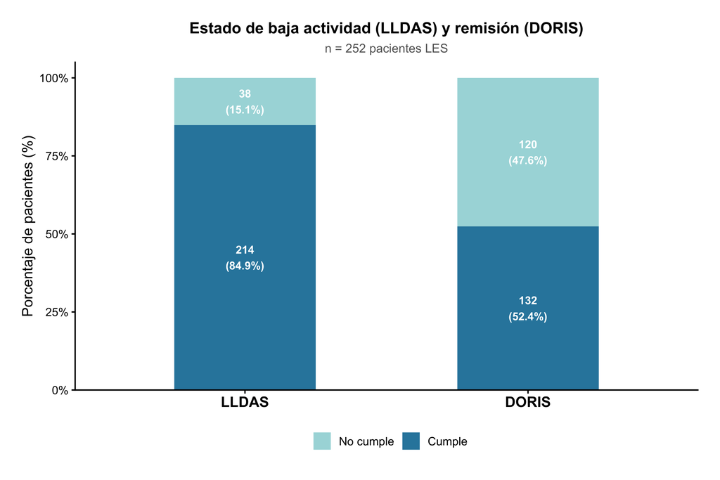

```r
estados_df <- data.frame(
  indice  = rep(c("LLDAS", "DORIS"), each = 2),
  estado  = rep(c("Cumple", "No cumple"), 2),
  n       = c(214, 38, 132, 120),
  pct     = c(84.9, 15.1, 52.4, 47.6)
)
estados_df$indice <- factor(estados_df$indice, levels = c("LLDAS", "DORIS"))
estados_df$estado <- factor(estados_df$estado, levels = c("No cumple", "Cumple"))

ggplot(estados_df, aes(x = indice, y = pct, fill = estado)) +
  geom_col(width = 0.5) +
  geom_text(aes(label = paste0(n, "\n(", pct, "%)")),
            position = position_stack(vjust = 0.5),
            size = 3.5, fontface = "bold", color = "white") +
  scale_fill_manual(values = c("Cumple" = "#2E86AB", "No cumple" = "#A8DADC"), name = "") +
  scale_y_continuous(limits = c(0, 105), expand = c(0, 0),
                     labels = function(x) paste0(x, "%")) +
  labs(title    = "Estado de baja actividad (LLDAS) y remisión (DORIS)",
       subtitle = "n = 252 pacientes LES",
       x = NULL, y = "Porcentaje de pacientes (%)") +
  theme_classic(base_family = "Arial", base_size = 13) +
  theme(plot.title      = element_text(face = "bold", size = 14, hjust = 0.5),
        plot.subtitle   = element_text(size = 11, hjust = 0.5, color = "grey40"),
        legend.position = "bottom",
        axis.text.x     = element_text(size = 13, face = "bold"),
        plot.margin     = margin(20, 20, 20, 20))
```

# 9 Guardado de objetos

Los datos con los índices calculados junto con las variables demográficas, séricas y de expresión se guardan para su uso en análisis posteriores (análisis descriptivo, firma interferónica, integración multi-ómica).

```r
# Variables séricas y analíticas
vars_sericas <- c(
  "pcrmgl", "creatinina", "colesterol", "trigli", "hdl", "ldl",
  "apoa1", "apob", "apoba", "lipoprotein a",
  "glucosa", "insulinauuml", "pepcngml",
  "glucosanmoll", "insulinapmoll", "pepcnmoll",
  "homair", "homas", "homab",
  "c3", "c4",
  "got", "gpt", "ggt", "prot tot"
)

# Genes ISG
genes_isg <- c(
  "BDCA1", "BST2", "CEACAM1", "CMPK2", "CXCL10", "CXCL9", "DDX60",
  "DNAJA1", "EIFAK2", "EPSTI1", "GBP1", "GBP4", "GBP5", "HERC5", "HERC6",
  "IFI16", "IFI27", "IFI35", "IFI44", "IFI44L", "IFI6", "IFIH1", "IFIT1",
  "IFIT2", "IFIT3", "IFIT5", "IFITM1", "IFITM3", "IL1RN", "IL6", "IRF1",
  "IRF7", "ISG15", "ISG20", "LAMP3", "LGALS3BP", "LY6E", "MX1", "MX2",
  "MYD88", "NC0A7", "NT5C3B", "OAS1", "OAS2", "OAS3", "OASL", "PARP12",
  "PARP9", "PHF11", "PLSCR1", "PRKR", "PSMB9", "RSAD2", "RTP4", "SAMD9L",
  "SERPING1", "SIGLEC1", "SOCS1", "SP100", "SP140", "SPATS2L", "STAT1",
  "TAP1", "TNFAIP6", "TNFSF10", "TRIM38", "TYK2", "UB2L6", "UNC93B1",
  "USP18", "XAF1", "ZBP1"
)

# Housekeeping
genes_hk <- c("alas1", "g6pd", "hprt1", "polr2a", "tbp")

# Sondas de control NanoString
sondas_ctrl <- c(
  "NEG_A", "NEG_B", "NEG_C", "NEG_D", "NEG_E", "NEG_F",
  "POS_A", "POS_B", "POS_C", "POS_D", "POS_E", "POS_F"
)

# Crear DataSet_scores
DataSet_scores <- DataSet_bruto %>%
  rename(
    IFNapgml = `IFNαpg/ml`,
    IFNgpgml = `IFNγpg/ml`,
    IL2pgml  = `IL2pg/ml`,
    IL6pgml  = `IL6pg/ml`,
    IL8pgml  = `IL8pg/ml`,
    baffpgml = `baffpg/ml`
  ) %>%
  select(
    id2, varon1, les,
    edad, duracion, edadiag,
    sledai, slicc, sledas, lldas, doris,
    any_of(vars_sericas),
    IFNapgml, IFNgpgml, IL2pgml, IL6pgml, IL8pgml, baffpgml,
    all_of(genes_isg),
    all_of(genes_hk),
    all_of(sondas_ctrl)
  )

cat("Dimensiones de DataSet_scores:", nrow(DataSet_scores), "filas x", ncol(DataSet_scores), "columnas\n")
```

```
## Dimensiones de DataSet_scores: 276 filas x 131 columnas
```

```r
# Guardar
saveRDS(DataSet_scores, "DataSet_scores.rds")
cat("✔ Guardado: DataSet_scores.rds\n")
```

```
## ✔ Guardado: DataSet_scores.rds
```

# 10 Análisis Descriptivo

Este apartado presenta el análisis descriptivo de las variables clínicas, los índices de actividad y daño, y las variables séricas y analíticas recogidas en la visita de estudio. Los resultados se presentan de forma separada para pacientes con LES y controles sanos. Las variables continuas se expresan como media ± desviación estándar (DE) cuando siguen distribución normal (test de Shapiro-Wilk, p ≥ 0,05), o como mediana [rango intercuartílico, IQR] en caso contrario. Las variables categóricas se expresan como N (%).

```r
les  <- DataSet_scores %>% filter(les == "LES")
ctrl <- DataSet_scores %>% filter(les == "Control")

desc_continua <- function(df, var, label) {
  x <- df[[var]]; x <- x[!is.na(x)]; n_valid <- length(x)
  if (n_valid == 0)
    return(tibble(Variable = label, `N válido` = 0,
                  `Media±DE / Mediana[IQR]` = "—"))
  if (n_valid == 1)
    return(tibble(Variable = label, `N válido` = 1,
                  `Media±DE / Mediana[IQR]` = as.character(round(x, 2))))
  sw_p <- if (n_valid >= 3 & n_valid <= 5000)
    tryCatch(shapiro.test(x)$p.value, error = function(e) NA) else NA
  normal <- !is.na(sw_p) && sw_p >= 0.05
  res <- if (normal) paste0(round(mean(x), 2), " ± ", round(sd(x), 2)) else
    paste0(round(median(x), 2),
           " [", round(quantile(x, 0.25), 2),
           "–",  round(quantile(x, 0.75), 2), "]")
  tibble(Variable = label, `N válido` = n_valid,
         `Media±DE / Mediana[IQR]` = res)
}

desc_categorica <- function(df, var, label) {
  x <- df[[var]]; tab <- table(x, useNA = "no"); total <- sum(tab)
  if (total == 0)
    return(tibble(Variable = label, `N válido` = 0,
                  `Media±DE / Mediana[IQR]` = "—"))
  tibble(
    Variable = paste0(label, ": ", names(tab)),
    `N válido` = as.integer(tab),
    `Media±DE / Mediana[IQR]` = paste0(round(as.integer(tab)/total*100, 1), "%")
  )
}

desc_cat_tabla <- function(df, var, label) {
  x <- df[[var]]; tab <- table(x, useNA = "no"); total <- sum(tab)
  if (total == 0)
    return(tibble(Variable = label, `N válido` = 0, `Valor` = "—"))
  bind_rows(
    tibble(Variable = label, `N válido` = total, `Valor` = "—"),
    tibble(Variable = paste0("  · ", names(tab)),
           `N válido` = as.integer(tab),
           `Valor` = paste0(round(as.integer(tab)/total*100, 1), "%"))
  )
}

fila_continua <- function(df, var, label) {
  x <- df[[var]]; x <- x[!is.na(x)]; n <- length(x)
  if (n == 0) return(tibble(Variable = label, N = 0, Resultado = "—"))
  if (n == 1) return(tibble(Variable = label, N = 1,
                             Resultado = as.character(round(x, 2))))
  sw_p <- tryCatch(shapiro.test(x)$p.value, error = function(e) NA)
  normal <- !is.na(sw_p) && sw_p >= 0.05
  res <- if (normal) paste0(round(mean(x), 2), " ± ", round(sd(x), 2)) else
    paste0(round(median(x), 2),
           " [", round(quantile(x, 0.25), 2),
           "–",  round(quantile(x, 0.75), 2), "]")
  tibble(Variable = label, N = n, Resultado = res)
}

fila_categorica <- function(df, var, label) {
  x <- df[[var]]; tab <- table(x, useNA = "no"); total <- sum(tab)
  if (total == 0) return(tibble(Variable = label, N = 0, Resultado = "—"))
  bind_rows(
    tibble(Variable = label, N = total, Resultado = "—"),
    tibble(Variable = paste0("  · ", names(tab)),
           N = as.integer(tab),
           Resultado = paste0(as.integer(tab), " (",
                              round(as.integer(tab)/total*100, 1), "%)"))
  )
}
```

## 10.1 Variables demográficas y clínicas

```r
vars_demo <- list(
  list(var = "edad",     label = "Edad (años)",               tipo = "cont"),
  list(var = "varon1",   label = "Sexo",                      tipo = "cat"),
  list(var = "duracion", label = "Duración enfermedad (años)", tipo = "cont"),
  list(var = "edadiag",  label = "Edad al diagnóstico (años)", tipo = "cont")
)

tabla_demo_les  <- bind_rows(lapply(vars_demo, function(v)
  if (v$tipo == "cont") desc_continua(les,  v$var, v$label)
  else                  desc_categorica(les, v$var, v$label)))

tabla_demo_ctrl <- bind_rows(lapply(vars_demo, function(v)
  if (v$tipo == "cont") desc_continua(ctrl,  v$var, v$label)
  else                  desc_categorica(ctrl, v$var, v$label)))

left_join(tabla_demo_les, tabla_demo_ctrl,
          by = "Variable", suffix = c(" LES", " Control")) %>%
  kable(caption = "Tabla 1. Características demográficas (LES vs. Controles)",
        align = c("l", "r", "r", "r", "r")) %>%
  kable_styling(bootstrap_options = c("striped", "hover"), full_width = FALSE)
```

Tabla 1. Características demográficas (LES vs. Controles)

| Variable | N válido LES | Media±DE / Mediana[IQR] LES | N válido Control | Media±DE / Mediana[IQR] Control |
| --- | --- | --- | --- | --- |
| Edad (años) | 252 | 52.5 ± 11.51 | 24 | 53.04 ± 7.49 |
| Sexo: Mujer | 227 | 90.1% | 22 | 91.7% |
| Sexo: Varón | 25 | 9.9% | 2 | 8.3% |
| Duración enfermedad (años) | 252 | 19.43 [10.27–27.47] | 0 | — |
| Edad al diagnóstico (años) | 252 | 30.65 [23.54–41.18] | 0 | — |

## 10.2 Índices de actividad y daño (pacientes LES)

```r
les <- DataSet_scores %>% filter(les == "LES") %>%
  mutate(
    sledai_cat = factor(case_when(
      sledai == 0                  ~ "Remisión (0)",
      sledai >= 1 & sledai <= 5    ~ "Leve (1–5)",
      sledai >= 6 & sledai <= 10   ~ "Moderada (6–10)",
      sledai >= 11 & sledai <= 19  ~ "Alta (11–19)",
      sledai >= 20                 ~ "Muy alta (≥20)"
    ), levels = c("Remisión (0)", "Leve (1–5)", "Moderada (6–10)",
                  "Alta (11–19)", "Muy alta (≥20)")),

    sledas_cat = factor(case_when(
      sledas <= 2.08                  ~ "Remisión (≤2.08)",
      sledas > 2.08 & sledas <= 7.64  ~ "Leve (>2.08–≤7.64)",
      sledas > 7.64                   ~ "Moderada-grave (>7.64)"
    ), levels = c("Remisión (≤2.08)", "Leve (>2.08–≤7.64)",
                  "Moderada-grave (>7.64)"))
  )

# Funciones con columna unificada "Resultado"
fila_continua <- function(df, var, label) {
  x <- df[[var]]; x <- x[!is.na(x)]; n <- length(x)
  if (n == 0) return(tibble(Variable = label, N = 0, Resultado = "Sin datos"))
  if (n == 1) return(tibble(Variable = label, N = 1,
                             Resultado = as.character(round(x, 2))))
  sw_p <- tryCatch(shapiro.test(x)$p.value, error = function(e) NA)
  normal <- !is.na(sw_p) && sw_p >= 0.05
  res <- if (normal) paste0(round(mean(x), 2), " ± ", round(sd(x), 2)) else
    paste0(round(median(x), 2),
           " [", round(quantile(x, 0.25), 2),
           "–",  round(quantile(x, 0.75), 2), "]")
  tibble(Variable = label, N = n, Resultado = res)
}

fila_categorica <- function(df, var, label) {
  x <- df[[var]]; tab <- table(x, useNA = "no"); total <- sum(tab)
  if (total == 0) return(tibble(Variable = label, N = 0, Resultado = "Sin datos"))
  bind_rows(
    tibble(Variable = label,                   N = total, Resultado = "—"),
    tibble(Variable = paste0("  · ", names(tab)),
           N = as.integer(tab),
           Resultado = paste0(as.integer(tab), " (",
                              round(as.integer(tab)/total*100, 1), "%)"))
  )
}

# Construir Tabla 2
tabla2 <- bind_rows(
  fila_continua(les,   "sledai",     "SLEDAI-2K"),
  fila_categorica(les, "sledai_cat", "  Categoría SLEDAI-2K"),
  fila_continua(les,   "slicc",      "SLICC/SDI"),
  fila_continua(les,   "sledas",     "SLE-DAS"),
  fila_categorica(les, "sledas_cat", "  Categoría SLE-DAS"),
  fila_categorica(les, "lldas",      "LLDAS"),
  fila_categorica(les, "doris",      "DORIS")
)

kable(tabla2,
      col.names = c("Variable", "N válido", "Resultado"),
      caption   = "Tabla 2. Índices de actividad y daño en pacientes LES",
      align     = c("l", "r", "r")) %>%
  kable_styling(bootstrap_options = c("striped", "hover"),
                full_width = FALSE) %>%
  row_spec(which(!grepl("^  ·", tabla2$Variable)), bold = TRUE)
```

Tabla 2. Índices de actividad y daño en pacientes LES

| Variable | N válido | Resultado |
| --- | --- | --- |
| SLEDAI-2K | 252 | 2 [0–4] |
| Categoría SLEDAI-2K | 252 | — |
| · Remisión (0) | 109 | 109 (43.3%) |
| · Leve (1–5) | 122 | 122 (48.4%) |
| · Moderada (6–10) | 21 | 21 (8.3%) |
| · Alta (11–19) | 0 | 0 (0%) |
| · Muy alta (≥20) | 0 | 0 (0%) |
| SLICC/SDI | 252 | 0 [0–1] |
| SLE-DAS | 252 | 1.12 [0.37–2.08] |
| Categoría SLE-DAS | 252 | — |
| · Remisión (≤2.08) | 197 | 197 (78.2%) |
| · Leve (>2.08–≤7.64) | 43 | 43 (17.1%) |
| · Moderada-grave (>7.64) | 12 | 12 (4.8%) |
| LLDAS | 252 | — |
| · 0 | 38 | 38 (15.1%) |
| · 1 | 214 | 214 (84.9%) |
| DORIS | 252 | — |
| · 0 | 120 | 120 (47.6%) |
| · 1 | 132 | 132 (52.4%) |

## 10.3 Variables séricas y analíticas

```r
vars_sericas_list <- list(
  list(var = "pcrmgl",        label = "PCR (mg/L)"),
  list(var = "creatinina",    label = "Creatinina"),
  list(var = "colesterol",    label = "Colesterol total"),
  list(var = "trigli",        label = "Triglicéridos"),
  list(var = "hdl",           label = "HDL"),
  list(var = "ldl",           label = "LDL"),
  list(var = "apoa1",         label = "Apolipoproteína A1"),
  list(var = "apob",          label = "Apolipoproteína B"),
  list(var = "apoba",         label = "Apolipoproteína(a)"),
  list(var = "lipoprotein a", label = "Lipoproteína(a)"),
  list(var = "glucosa",       label = "Glucosa"),
  list(var = "insulinauuml",  label = "Insulina (µU/mL)"),
  list(var = "pepcngml",      label = "Péptido C (ng/mL)"),
  list(var = "homair",        label = "HOMA-IR"),
  list(var = "homas",         label = "HOMA-S"),
  list(var = "homab",         label = "HOMA-B"),
  list(var = "c3",            label = "Complemento C3"),
  list(var = "c4",            label = "Complemento C4"),
  list(var = "got",           label = "GOT/AST"),
  list(var = "gpt",           label = "GPT/ALT"),
  list(var = "ggt",           label = "GGT"),
  list(var = "prot tot",      label = "Proteínas totales"),
  list(var = "IFNapgml",      label = "IFN-α (pg/mL)"),
  list(var = "IFNgpgml",      label = "IFN-γ (pg/mL)"),
  list(var = "IL2pgml",       label = "IL-2 (pg/mL)"),
  list(var = "IL6pgml",       label = "IL-6 (pg/mL)"),
  list(var = "IL8pgml",       label = "IL-8 (pg/mL)"),
  list(var = "baffpgml",      label = "BAFF (pg/mL)")
)

tabla3 <- bind_rows(lapply(vars_sericas_list, function(v)
  fila_continua(les, v$var, v$label)))

kable(tabla3,
      col.names = c("Variable", "N válido", "Resultado"),
      caption   = "Tabla 3. Variables séricas y analíticas en pacientes LES",
      align     = c("l", "r", "r")) |>
  kable_styling(bootstrap_options = c("striped", "hover"), full_width = FALSE)
```

Tabla 3. Variables séricas y analíticas en pacientes LES

| Variable | N válido | Resultado |
| --- | --- | --- |
| PCR (mg/L) | 246 | 1.88 [0.76–4.24] |
| Creatinina | 247 | 0.73 [0.63–0.89] |
| Colesterol total | 247 | 178.74 ± 38.59 |
| Triglicéridos | 247 | 93.4 [72.85–125.05] |
| HDL | 247 | 52.6 [44.8–62.95] |
| LDL | 247 | 98.9 [80.61–122.55] |
| Apolipoproteína A1 | 246 | 154 [136–168] |
| Apolipoproteína B | 246 | 83.4 [68.85–96.05] |
| Apolipoproteína(a) | 245 | 0.53 [0.44–0.65] |
| Lipoproteína(a) | 246 | 38.55 [9.43–128.56] |
| Glucosa | 247 | 87 [82–96] |
| Insulina (µU/mL) | 249 | 8.86 [5.7–16.18] |
| Péptido C (ng/mL) | 249 | 2.18 [1.51–2.97] |
| HOMA-IR | 246 | 1 [0.6–1.8] |
| HOMA-S | 246 | 99.8 [56.73–156.67] |
| HOMA-B | 245 | 129.8 [104.1–173.5] |
| Complemento C3 | 247 | 128.8 [106.5–154.95] |
| Complemento C4 | 247 | 18.9 [12.95–25.6] |
| GOT/AST | 68 | 20 [17–24.5] |
| GPT/ALT | 68 | 17 [14–23.5] |
| GGT | 53 | 20 [13–27] |
| Proteínas totales | 62 | 7.08 ± 0.51 |
| IFN-α (pg/mL) | 244 | 0.19 [0.04–1.38] |
| IFN-γ (pg/mL) | 250 | 0.44 [0.25–0.95] |
| IL-2 (pg/mL) | 178 | 0.11 [0.08–0.17] |
| IL-6 (pg/mL) | 178 | 4.26 [2.65–7.62] |
| IL-8 (pg/mL) | 178 | 10.05 [7.4–13.97] |
| BAFF (pg/mL) | 82 | 493 [388.81–896.43] |

# 11 Referencias Índices clínicos

- **SLEDAI-2K**: Gladman DD et al. *J Rheumatol.* 2002;29(2):288–91.
- **SLICC/SDI**: Gladman DD et al. *Arthritis Rheum.* 1996;39(3):363–9.
- **SLE-DAS**: Jorge AM et al. *Ann Rheum Dis.* 2019;78(3):365–71.
- **SLE-DAS remisión y categorías**: Jesus D et al. *Ann Rheum Dis.* 2021;80(12):1568–74.
- **LLDAS**: Franklyn K et al. *Ann Rheum Dis.* 2016;75(9):1615–21.
- **DORIS**: van Vollenhoven RF et al. *Ann Rheum Dis.* 2021;80(6):736–45.

```r
library(ggplot2)

# Definir centros y alturas
# Cajas azules: centro_A=9.9, centro_B=7.4, centro_C=4.9, centro_F=2.1
# Cajas rojas: mismo centro que su azul correspondiente

# Alturas de cajas rojas (proporcional al contenido)
h_ex1 <- 1.8   # 5 líneas
h_ex2 <- 1.2   # 3 líneas
h_ex3 <- 0.9   # 2 líneas

png("Fig1_Diagrama_Flujo.png", width = 4000, height = 3600, res = 300)

ggplot() +

  # ── CAJAS AZULES ──────────────────────────────────────────────────────────

  # A: centro=9.9
  annotate("rect", xmin=1, xmax=5.2, ymin=9.3, ymax=10.5,
           fill="#EAF4FB", color="#2E86AB", linewidth=1.3) +
  annotate("text", x=3.1, y=9.9,
           label="Pacientes preseleccionados con\ndiagnóstico clínico de LES\nn = 400",
           size=5.0, family="sans", hjust=0.5) +

  # B: centro=7.4
  annotate("rect", xmin=1, xmax=5.2, ymin=6.8, ymax=8.0,
           fill="#EAF4FB", color="#2E86AB", linewidth=1.3) +
  annotate("text", x=3.1, y=7.4,
           label="Pacientes elegibles tras criterios\nde inclusión / exclusión\nn = 313",
           size=5.0, family="sans", hjust=0.5) +

  # C: centro=4.9
  annotate("rect", xmin=1, xmax=5.2, ymin=4.3, ymax=5.5,
           fill="#EAF4FB", color="#2E86AB", linewidth=1.3) +
  annotate("text", x=3.1, y=4.9,
           label="Muestra analítica final\n(datos clínicos + biomarcadores séricos)\nn = 252 LES",
           size=5.0, family="sans", hjust=0.5) +

  # F: centro=2.1
  annotate("rect", xmin=1, xmax=5.2, ymin=1.5, ymax=2.7,
           fill="#EAF4FB", color="#2E86AB", linewidth=1.3) +
  annotate("text", x=3.1, y=2.1,
           label="Cohorte transcriptómica final\n(IFN-score · 72 ISGs · NanoString nCounter)\nn = 251 LES  +  24 controles",
           size=5.0, family="sans", hjust=0.5) +

  # Controles sanos: centro=2.1 (mismo nivel que F)
  annotate("rect", xmin=6.5, xmax=10.5, ymin=1.5, ymax=2.7,
           fill="#EAF4FB", color="#2E86AB", linewidth=1.3) +
  annotate("text", x=8.5, y=2.1,
           label="Controles sanos\n(frecuencia-pareados por edad y sexo)\nn = 24",
           size=5.0, family="sans", hjust=0.5) +

  # ── CAJAS ROJAS (centradas exactamente igual que su caja azul) ────────────

  # EX1: centro=9.9, altura=1.8 → ymin=9.0, ymax=10.8
  annotate("rect", xmin=6.5, xmax=11.2, ymin=9.0, ymax=10.8,
           fill="#FADBD8", color="#E74C3C", linewidth=1.1) +
  annotate("text", x=8.85, y=9.9,
           label="Excluidos  (n = 87)\n· No cumplen ≥4 criterios ACR: n = 45 (11,3%)\n· Consentimiento incompleto: n = 20 (5,0%)\n· Tratamiento con anifrolumab: n = 12 (3,0%)\n· Muestras séricas inadecuadas: n = 10 (2,5%)",
           size=4.5, family="sans", hjust=0.5, color="#7B241C") +

  # EX2: centro=7.4, altura=1.2 → ymin=6.8, ymax=8.0
  annotate("rect", xmin=6.5, xmax=11.2, ymin=6.8, ymax=8.0,
           fill="#FADBD8", color="#E74C3C", linewidth=1.1) +
  annotate("text", x=8.85, y=7.4,
           label="Excluidos del análisis transcriptómico  (n = 61)\n· Sin datos NanoString completos\n  o fallo en control de calidad (QC)",
           size=4.5, family="sans", hjust=0.5, color="#7B241C") +

  # EX3: centro=4.9, altura=0.9 → ymin=4.45, ymax=5.35
  annotate("rect", xmin=6.5, xmax=11.2, ymin=4.45, ymax=5.35,
           fill="#FADBD8", color="#E74C3C", linewidth=1.1) +
  annotate("text", x=8.85, y=4.9,
           label="Excluido: fallo en normalización NanoString  (n = 1)",
           size=4.5, family="sans", hjust=0.5, color="#7B241C") +

  # ── FLECHAS AZULES VERTICALES ─────────────────────────────────────────────
  annotate("segment", x=3.1, xend=3.1, y=9.3, yend=8.0,
           color="#2E86AB", linewidth=1.5,
           arrow=arrow(length=unit(0.3,"cm"), type="closed")) +
  annotate("segment", x=3.1, xend=3.1, y=6.8, yend=5.5,
           color="#2E86AB", linewidth=1.5,
           arrow=arrow(length=unit(0.3,"cm"), type="closed")) +
  annotate("segment", x=3.1, xend=3.1, y=4.3, yend=2.7,
           color="#2E86AB", linewidth=1.5,
           arrow=arrow(length=unit(0.3,"cm"), type="closed")) +

  # ── FLECHAS ROJAS HORIZONTALES PURAS ─────────────────────────────────────
  # Sale del borde derecho de la caja azul (x=5.2)
  # al mismo centro vertical → entra por el borde izquierdo de la roja (x=6.5)

  # A → EX1: y=9.9
  annotate("segment", x=5.2, xend=6.5, y=9.9, yend=9.9,
           color="#E74C3C", linewidth=1.2, linetype="dashed",
           arrow=arrow(length=unit(0.25,"cm"), type="open")) +

  # B → EX2: y=7.4
  annotate("segment", x=5.2, xend=6.5, y=7.4, yend=7.4,
           color="#E74C3C", linewidth=1.2, linetype="dashed",
           arrow=arrow(length=unit(0.25,"cm"), type="open")) +

  # C → EX3: y=4.9
  annotate("segment", x=5.2, xend=6.5, y=4.9, yend=4.9,
           color="#E74C3C", linewidth=1.2, linetype="dashed",
           arrow=arrow(length=unit(0.25,"cm"), type="open")) +

  # ── FLECHA CONTROLES → F: y=2.1 ──────────────────────────────────────────
  annotate("segment", x=6.5, xend=5.2, y=2.1, yend=2.1,
           color="#888888", linewidth=1.1, linetype="dashed",
           arrow=arrow(length=unit(0.25,"cm"), type="open")) +

  # ── Estilo ────────────────────────────────────────────────────────────────
  scale_x_continuous(limits=c(0.5, 11.8), expand=c(0,0)) +
  scale_y_continuous(limits=c(1.0, 11.2), expand=c(0,0)) +
  theme_void() +
  theme(plot.background = element_rect(fill="white", color=NA),
        plot.margin = margin(50, 50, 50, 50))

dev.off()
```